# Clean LENA 5-minute data

Lucy King

02/08/2020

## Environment set up

```r
# Libraries
library(tidyverse)
library(lubridate)
library(hms)
library(psych)
# Files
lena_5min_file_1 <- "~/Box/Mooddata_Coordinating/BABIES/Data/final_scored_data/LENA/raw_5min_data/LENAExport_5Minute_20181220_cleaned.csv"
lena_5min_file_2 <- "~/Box/Mooddata_Coordinating/BABIES/Data/final_scored_data/LENA/raw_5min_data/LENAExport_5Minute_new_20190726.csv"
lena_5min_files_old <- "~/Box/Mooddata_Coordinating/BABIES/Data/final_scored_data/LENA/raw_5min_data/individual_5min_lsk_format_cleaned"
lena_5min_files_new <- "~/Box/Mooddata_Coordinating/BABIES/Data/final_scored_data/LENA/raw_5min_data/individual_5min_fq_cleaned_20200207"
lena_followup_day1_cs_file <- "~/Box/Mooddata_Coordinating/BABIES/Data/final_scored_data/LENA/raw_followupQs_data/LENA_followup_day1_cs_complete.csv"
lena_followup_day2_cs_file <- "~/Box/Mooddata_Coordinating/BABIES/Data/final_scored_data/LENA/raw_followupQs_data/LENA_followup_day2_cs_complete.csv"
lena_followup_day1_lg_file <- "~/Box/Mooddata_Coordinating/BABIES/Data/final_scored_data/LENA/raw_followupQs_data/LENA_followup_day1_lg_complete.csv"
lena_followup_day2_lg_file <- "~/Box/Mooddata_Coordinating/BABIES/Data/final_scored_data/LENA/raw_followupQs_data/LENA_followup_day2_lg_complete.csv"
lena_5min_old_files_df <-
  tibble(
    path =
      list.files(
        path = lena_5min_files_old,
        all.files = TRUE,
        no.. = TRUE,
        full.names = TRUE
      )
  ) %>%
  filter(
    str_detect(path, "/.DS_Store") == FALSE
  )
lena_5min_new_files_df <-
  tibble(
    path =
      list.files(
        path = lena_5min_files_new,
        all.files = TRUE,
        no.. = TRUE,
        full.names = TRUE
      )
  ) %>%
  filter(
    str_detect(path, "/.DS_Store") == FALSE
  )
# Functions
source("~/Box/Mooddata_Coordinating/BABIES/Data/final_scored_data/identify_outliers_histogram.R")
source("~/Box/Mooddata_Coordinating/BABIES/Data/final_scored_data/winsorize.R")
# Themes
theme_lena <-
  theme_minimal() +
  theme(
    panel.grid = element_blank(),
    plot.title = element_text(size = 18, hjust = .5),
    axis.title = element_text(size = 18),
    axis.text = element_text(size = 16),
    legend.title = element_text(size = 18),
    legend.text = element_text(size = 16),
    legend.position = "bottom"
  )
```

# Read in and reformat 5 minute data from LENA SP

```r
lena_5min_sp <-
  read_csv(lena_5min_file_2) %>%
  mutate(
    ExternalReferenceID = as.integer(ExternalReferenceID),
    Recording_DOB = as.character(Recording_DOB),
    StartTime = as.character(StartTime)
  ) %>%
  select(
    ExternalReferenceID,
    Recording_DOB,
    StartTime,
    Duration_Secs,
    AWC_COUNT,
    CT_COUNT,
    CV_COUNT,
    Recording_Gender,
    Meaningful,
    Distant,
    TV_Elec,
    Overlap,
    Noise,
    Silence
  ) %>%
  mutate(
    ID = ExternalReferenceID,
    dob = Recording_DOB,
    AWC.Actual = AWC_COUNT,
    CTC.Actual = CT_COUNT,
    CVC.Actual = CV_COUNT,
    Sex = Recording_Gender,
    Duration = as.hms(Duration_Secs),
    Meaningful = as.hms(Meaningful),
    Distant = as.hms(Distant),
    TV = as.hms(TV_Elec),
    Overlap = as.hms(Overlap),
    Noise = as.hms(Noise),
    Silence = as.hms(Silence),
    Timestamp = StartTime
  ) %>%
  select(
    -ExternalReferenceID,
    -Recording_DOB,
    -Recording_Gender,
    -CT_COUNT,
    -CV_COUNT,
    -AWC_COUNT,
    -Duration_Secs
  ) %>%
  mutate(
    Timestamp = str_replace(Timestamp, " \\(America/Los_Angeles\\)", ""),
    time_record = parse_date_time(Timestamp, "mdy HMS p!")
  ) %>%
  select(
    -Timestamp
  )
```

```
as.hms() is deprecated, please use as_hms().
```

## Read in 5-minute LENA Pro data and combine with LENA SP data

```r
lena_5min <-
  read_csv(lena_5min_file_1) %>%
  mutate(
    Birthdate = as.character(Birthdate),
    Timestamp = as.character(Timestamp),
    Meaningful = as.hms(Meaningful)
  ) %>%
  select(
    -Type,
    -ChildKey,
    -Id,
    -Age,
    -AVA_StdScore:-AVA_AvgScore_Pct,
    -Firstname,
    ID = Lastname,
    dob = Birthdate
  ) %>%
  mutate(
    time_record = parse_date_time(Timestamp, "mdy HM")
  ) %>%
  bind_rows(
    lena_5min_sp
  ) %>%
  mutate(
    ID = as.numeric(ID)
  ) %>%
  select(
    -Timestamp
  )
```

## Read in data from individual files (Pro license 1)

```r
lena_5min2_old <-
  lena_5min_old_files_df %>%
  mutate(
    data = map(
      path,
      read_csv,
      col_names = TRUE,
      col_types =
        list(
          Firstname = col_character(),
          Birthdate = col_character(),
          Timestamp = col_character(),
          AVA_StdScore = col_character(),
          Lastname = col_character(),
          Sex = col_character(),
          ChildKey = col_character()
        )
      )
  ) %>%
  unnest(data) %>%
  select(-path) %>%
  mutate(
    Birthdate = as.character(Birthdate),
    Timestamp = as.character(Timestamp)
  ) %>%
  select(
    -Type,
    -ChildKey,
    -Id,
    -Age,
    -AVA_StdScore:-AVA_AvgScore_Pct,
    ID1 = Firstname,
    ID2 = Lastname,
    dob = Birthdate
  ) %>%
  mutate(
    ID = as.numeric(
      if_else(
        is.na(ID2),
        ID1, ID2
      )
    ),
    time_record = parse_date_time(Timestamp, c("mdy HM", "ymd HM"))
  ) %>%
  select(
    ID,
    everything(),
    -Timestamp,
    -ID1,
    -ID2
  )
```

## Read in data from individual files (LENA SP)

```r
lena_5min2_new <-
  lena_5min_new_files_df %>%
  mutate(
    data = map(
      path,
      read_csv,
      col_names = TRUE,
      col_types =
        list(
          Recording_Gender = col_character(),
          ErrorCodes = col_character()
        )
    )
  ) %>%
  unnest(data) %>%
  mutate(
    ExternalReferenceID = as.integer(ExternalReferenceID),
    Recording_DOB = as.character(Recording_DOB),
    StartTime = as.character(StartTime)
  ) %>%
  select(
    ExternalReferenceID,
    Recording_DOB,
    StartTime,
    Duration_Secs,
    AWC_COUNT,
    CT_COUNT,
    CV_COUNT,
    Recording_Gender,
    Meaningful,
    Distant,
    TV_Elec,
    Overlap,
    Noise,
    Silence
  ) %>%
  mutate(
    ID = ExternalReferenceID,
    dob = Recording_DOB,
    AWC.Actual = AWC_COUNT,
    CTC.Actual = CT_COUNT,
    CVC.Actual = CV_COUNT,
    Sex = Recording_Gender,
    Duration = as.hms(Duration_Secs),
    Meaningful = as.hms(Meaningful),
    Distant = as.hms(Distant),
    TV = as.hms(TV_Elec),
    Overlap = as.hms(Overlap),
    Noise = as.hms(Noise),
    Silence = as.hms(Silence),
    Timestamp = StartTime
  ) %>%
  select(
    -ExternalReferenceID,
    -Recording_DOB,
    -Recording_Gender,
    -CT_COUNT,
    -CV_COUNT,
    -AWC_COUNT,
    -Duration_Secs
  ) %>%
  mutate(
    Timestamp = str_replace(Timestamp, " \\(America/Los_Angeles\\)", ""),
    time_record = parse_date_time(Timestamp, "mdy HMS p!")
  ) %>%
  select(
    -Timestamp
  )
```

## Combine all data

```r
lena_5min <-
  lena_5min %>%
  bind_rows(lena_5min2_old) %>%
  bind_rows(lena_5min2_new) %>%
  arrange(ID) %>%
  mutate(
    dob = parse_date_time(dob, c("Ymd", "mdy")),
    date_record = date(time_record),
    age = (dob %--% date_record) / months(1)
  )
```

# Clean 5-minute data to identify observations to retain

Retain observations that occured between ages 5-8 months Retain observations totaling at least 8 hours of recording

## Reformat data

```r
lena_5min_cl <-
  lena_5min %>%
  group_by(ID) %>%
  mutate(
    duration = as.numeric(
      as.duration(hms(as.numeric(Duration))),
      "hours"
    )
  ) %>%
  ungroup() %>%
  group_by(ID, date_record, age) %>%
  summarise(
    duration = sum(duration)
  ) %>%
  ungroup() %>%
  group_by(ID) %>%
  arrange(ID, date_record) %>%
  mutate(
    day_type = wday(date_record),
    day_type = if_else(day_type == 1 | day_type == 7, "weekend", "weekday"),
    day = 1:n()
  ) %>%
  ungroup()
```

## Identify who will be removed

```r
lena_5min_cl <-
  lena_5min_cl %>%
  mutate(
    age_exclude = if_else(
      age < 5 | age > 8,
      1, 0
    ),
    duration_exclude = if_else(
      duration < 8,
      1, 0
    ),
    include = if_else(
      age_exclude == 0 & duration_exclude == 0,
      1, 0
    )
  )
write_csv(lena_5min_cl, "~/Box/Mooddata_Coordinating/BABIES/Data/final_scored_data/LENA/inclusion_exclusion_final.csv")
```

```r
lena_5min_cl %>%
  count(age_exclude, duration_exclude)
```

| age_exclude | duration_exclude | n |
| --- | --- | --- |
| 0 | 0 | 152 |
| 0 | 1 | 59 |
| 1 | 0 | 36 |
| 1 | 1 | 10 |

```r
lena_5min_cl %>%
  count(include)
```

| include | n |
| --- | --- |
| 0 | 105 |
| 1 | 152 |

```r
lena_5min_cl <-
  lena_5min_cl %>%
  filter(age_exclude == 0 & duration_exclude == 0) %>%
  arrange(ID, date_record) %>%
  group_by(ID) %>%
  mutate(
    day = 1:n()
  ) %>%
  ungroup() %>%
  rename(
    baby_age_lena = age
  ) %>%
  select(-include)
lena_5min_cl %>%
  count(day)
```

| day | n |
| --- | --- |
| 1 | 102 |
| 2 | 50 |

```r
lena_5min_cl %>%
  count(day_type)
```

| day_type | n |
| --- | --- |
| weekday | 84 |
| weekend | 68 |

```r
lena_5min_cl %>%
  count(day, day_type)
```

| day | day_type | n |
| --- | --- | --- |
| 1 | weekday | 65 |
| 1 | weekend | 37 |
| 2 | weekday | 19 |
| 2 | weekend | 31 |

```r
write_csv(lena_5min_cl, "~/Box/Mooddata_Coordinating/BABIES/Data/final_scored_data/LENA/included_final.csv")
```

# Read in LENA follow-up data

```r
lena_followup_cs_day1 <-
  read_csv(lena_followup_day1_cs_file) %>%
  rename(ID = record_id) %>%
  mutate(ID = as.integer(ID), day = 1) %>%
  filter(lena_day_1_followup_questions_complete == 2) %>%
  select(ID, day, lena_caregivers___1:lena_notes)
lena_followup_cs_day2 <-
  read_csv(lena_followup_day2_cs_file) %>%
  rename_all(
    funs(str_replace(., "_2", ""))
  ) %>%
  rename(ID = record_id) %>%
  mutate(ID = as.integer(ID), day = 2) %>%
  filter(lena_day_followup_questions_complete == 2) %>%
  select(ID, day, lena_caregivers___1:lena_notes)
```

```
NAs introduced by coercion
```

```r
lena_followup_lg_day1 <-
  read_csv(lena_followup_day1_lg_file) %>%
  rename(ID = record_id) %>%
  mutate(ID = as.integer(ID), day = 1) %>%
  filter(lena_day_1_followup_questions_complete == 2) %>%
  select(ID, day, lena_caregivers___1:lena_notes)
lena_followup_lg_day2 <-
  read_csv(lena_followup_day2_lg_file) %>%
  rename_all(
    funs(str_replace(., "_2", ""))
  ) %>%
  rename(ID = record_id) %>%
  mutate(ID = as.integer(ID), day = 2) %>%
  filter(lena_day_followup_questions_complete == 2) %>%
  select(ID, day, lena_caregivers___1:lena_notes)
lena_followup <-
  lena_followup_cs_day1 %>%
  bind_rows(
    lena_followup_cs_day2
  ) %>%
  bind_rows(
    lena_followup_lg_day1
  ) %>%
  bind_rows(
    lena_followup_lg_day2
  ) %>%
  select(
    -lena_prob:-lena_notes
  )
```

# Compute LENA metrics

## Create long-form data frame with time variables

```r
lena_time <-
  lena_5min %>%
  group_by(ID) %>%
  mutate(
    time_hours = hour(time_record) + minute(time_record) / 60,
    duration = as.numeric(
      as.duration(hms(as.numeric(Duration))),
      "hours"
    )
  )
```

## Filter raw 5-minute data to only include usable observations as determined above

```r
ids_dates_included <-
  lena_5min_cl %>%
  select(
    ID,
    date_record,
    day
  ) %>%
  mutate(
    included = 1,
    date_record = date(date_record)
  )
lena_time_cl <-
  lena_time %>%
  left_join(ids_dates_included, by = c("ID", "date_record")) %>%
  filter(included == 1)
```

## Identify value and times of first and last CT and AW of the day

```r
lena_time_cl <-
  lena_time_cl %>%
  arrange(ID, time_hours) %>%
  group_by(ID, day) %>%
  mutate(
    # first ct
    ct_first_row = head(which(CTC.Actual != 0), 1),
    ct_first = nth(CTC.Actual, n = ct_first_row[1]),
    ct_first_time = nth(time_hours, n = ct_first_row[1]),
    # last ct
    ct_last_row = tail(which(CTC.Actual != 0), 1),
    ct_last = nth(CTC.Actual, n = ct_last_row[1]),
    ct_last_time = nth(time_hours, n = ct_last_row[1]),
    # create grouping variable for time of day
    time_day = case_when(
      time_hours >= ct_first_time & time_hours <= 10 ~ "AM",
      time_hours >= 10 & time_hours < 13 ~ "MID",
      time_hours >= 13 & time_hours < 17 ~ "AFT",
      time_hours >= 17 & time_hours < ct_last_time ~ "PM"
    )
  ) %>%
  select(-ct_last_row, -ct_first_row) %>%
  # remove observations froms times of day before first CT or after last CT
  filter(!is.na(time_day))
```

## Compute hourly maximums

```r
min(lena_time_cl$time_hours, na.rm = TRUE)
```

```
[1] 5.5
```

```r
max(lena_time_cl$time_hours, na.rm = TRUE)
```

```
[1] 23.83333
```

```r
lena_hourly_max <-
  lena_time_cl %>%
  mutate(
    time_hours_round = round(time_hours)
  ) %>%
  group_by(ID, day, time_hours_round) %>%
  summarise(
    awc_hour_sum = sum(AWC.Actual),
    ctc_hour_sum = sum(CTC.Actual),
    cvc_hour_sum = sum(CVC.Actual)
  ) %>%
  group_by(ID, day) %>%
  summarise(
    awc_hour_max = max(awc_hour_sum),
    ctc_hour_max = max(ctc_hour_sum),
    cvc_hour_max = max(cvc_hour_sum)
  )
```

## Calculate rates and consistency during each phase of day and across each day

| ID | date_record | day | time_day | age | duration_time_day | ctc_time_day | awc_time_day | cvc_time_day | ctc_depend_time_day | awc_depend_time_day | ctc_max | awc_max | cvc_max | ctc_time_rate | awc_time_rate | cvc_time_rate | ctc_time_prop | awc_time_prop | ctc_rate | awc_rate | cvc_rate | ctc_prop | awc_prop |
| --- | --- | --- | --- | --- | --- | --- | --- | --- | --- | --- | --- | --- | --- | --- | --- | --- | --- | --- | --- | --- | --- | --- | --- |
| 2 | 2016-05-28 | 1 | AFT | 5.193548 | 4.00000000 | 123 | 6113 | 350 | 22 | 30 | 23 | 670 | 43 | 30.750000 | 1528.25000 | 87.50000 | 0.45833333 | 0.62500000 | 20.697987 | 1290.6040 | 64.34899 | 0.4697987 | 0.7114094 |
| 2 | 2016-05-28 | 1 | AM | 5.193548 | 2.50000000 | 60 | 3133 | 231 | 22 | 28 | 23 | 670 | 43 | 24.000000 | 1253.20000 | 92.40000 | 0.73333333 | 0.93333333 | 20.697987 | 1290.6040 | 64.34899 | 0.4697987 | 0.7114094 |
| 2 | 2016-05-28 | 1 | MID | 5.193548 | 2.91666667 | 50 | 3817 | 172 | 19 | 30 | 23 | 670 | 43 | 17.142857 | 1308.68571 | 58.97143 | 0.54285714 | 0.85714286 | 20.697987 | 1290.6040 | 64.34899 | 0.4697987 | 0.7114094 |
| 2 | 2016-05-28 | 1 | PM | 5.193548 | 3.00000000 | 24 | 2962 | 46 | 7 | 18 | 23 | 670 | 43 | 8.000000 | 987.33333 | 15.33333 | 0.19444444 | 0.50000000 | 20.697987 | 1290.6040 | 64.34899 | 0.4697987 | 0.7114094 |
| 2 | 2016-07-17 | 2 | AFT | 6.833333 | 4.00000000 | 81 | 3800 | 732 | 21 | 29 | 12 | 630 | 119 | 20.250000 | 950.00000 | 183.00000 | 0.43750000 | 0.60416667 | 17.343066 | 780.7883 | 133.92701 | 0.4160584 | 0.5693431 |
| 2 | 2016-07-17 | 2 | AM | 6.833333 | 3.25000000 | 42 | 2737 | 269 | 18 | 28 | 12 | 630 | 119 | 12.923077 | 842.15385 | 82.76923 | 0.46153846 | 0.71794872 | 17.343066 | 780.7883 | 133.92701 | 0.4160584 | 0.5693431 |
| 2 | 2016-07-17 | 2 | MID | 6.833333 | 2.91666667 | 16 | 273 | 132 | 5 | 6 | 12 | 630 | 119 | 5.485714 | 93.60000 | 45.25714 | 0.14285714 | 0.17142857 | 17.343066 | 780.7883 | 133.92701 | 0.4160584 | 0.5693431 |
| 2 | 2016-07-17 | 2 | PM | 6.833333 | 1.25000000 | 59 | 2104 | 396 | 13 | 15 | 12 | 630 | 119 | 47.200000 | 1683.20000 | 316.80000 | 0.86666667 | 1.00000000 | 17.343066 | 780.7883 | 133.92701 | 0.4160584 | 0.5693431 |
| 3 | 2016-06-17 | 1 | AFT | 6.677419 | 1.47611111 | 117 | 2525 | 466 | 18 | 18 | 21 | 852 | 49 | 79.262326 | 1710.57584 | 315.69439 | 1.00000000 | 1.00000000 | 48.920075 | 1775.7864 | 160.06846 | 0.6982714 | 0.8009584 |
| 3 | 2016-06-17 | 1 | AM | 6.677419 | 1.38250000 | 77 | 2388 | 317 | 14 | 15 | 21 | 852 | 49 | 55.696203 | 1727.30561 | 229.29476 | 0.84388186 | 0.90415913 | 48.920075 | 1775.7864 | 160.06846 | 0.6982714 | 0.8009584 |

[output cut: 584 more lines]

## Histograms

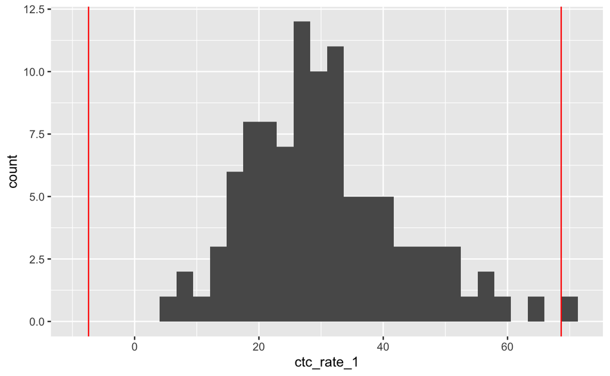

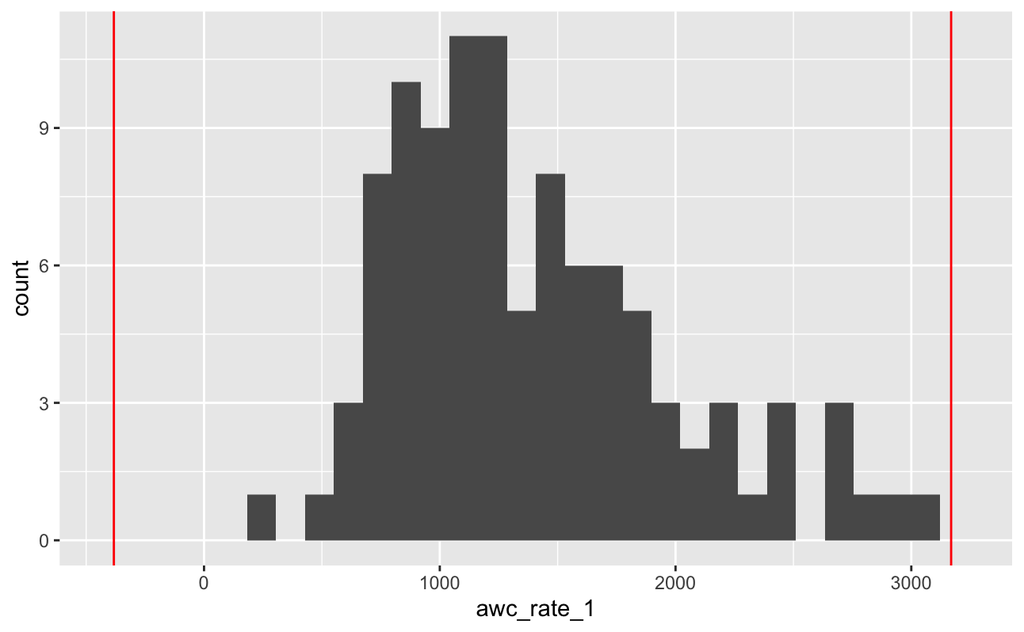

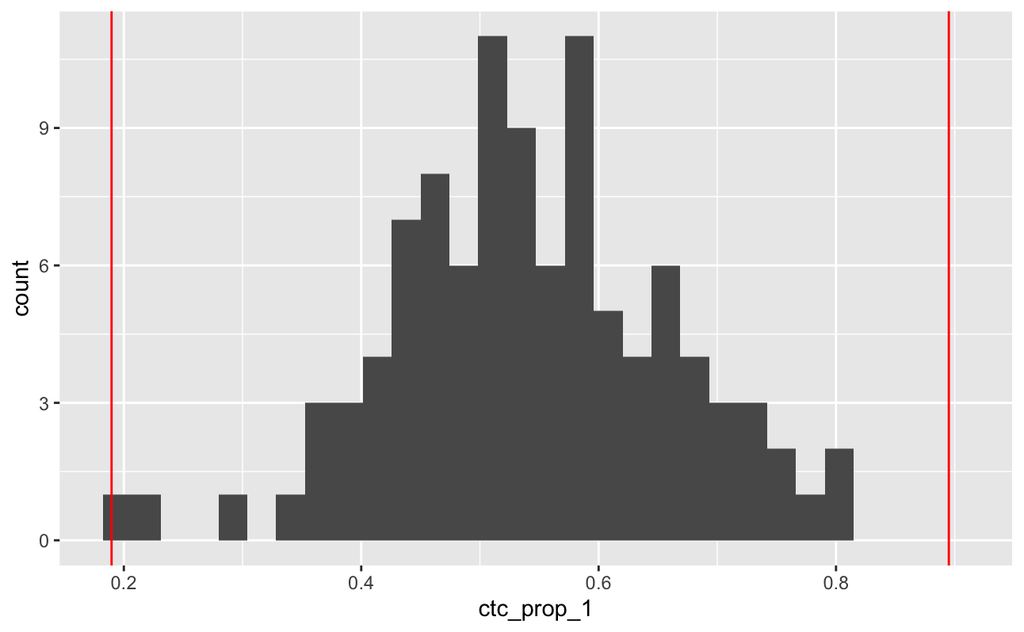

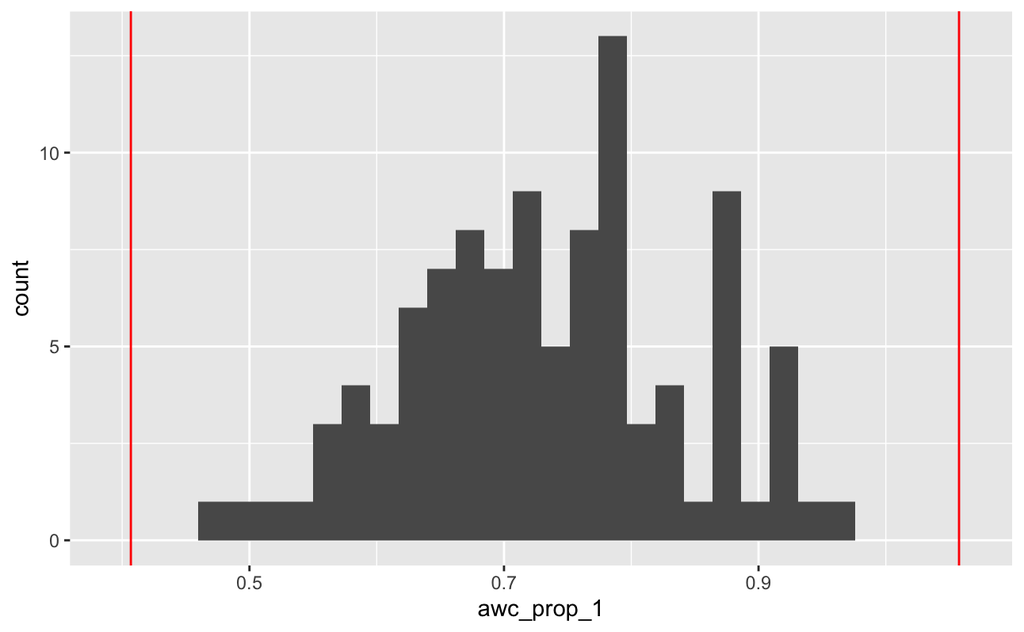

# LENA reliability

```
Model failed to converge with max|grad| = 0.0135117 (tol = 0.002, component 1)
Call: psych::ICC(x = .)

Intraclass correlation coefficients

 Number of subjects = 50     Number of Judges =  2
```

|  | type | ICC | F | df1 | df2 | p | lower bound | upper bound |
| --- | --- | --- | --- | --- | --- | --- | --- | --- |
| Single_raters_absolute | ICC1 | 0.1870095 | 1.460053 | 49 | 50 | 0.09299848 | -0.09192364 | 0.4393842 |
| Single_random_raters | ICC2 | 0.1870102 | 1.460056 | 49 | 49 | 0.09441634 | -0.09278720 | 0.4397815 |
| Single_fixed_raters | ICC3 | 0.1870105 | 1.460056 | 49 | 49 | 0.09441634 | -0.09376451 | 0.4402298 |
| Average_raters_absolute | ICC1k | 0.3150935 | 1.460053 | 49 | 50 | 0.09299848 | -0.20245796 | 0.6105169 |
| Average_random_raters | ICC2k | 0.3150945 | 1.460056 | 49 | 49 | 0.09441634 | -0.20455443 | 0.6109003 |
| Average_fixed_raters | ICC3k | 0.3150949 | 1.460056 | 49 | 49 | 0.09441634 | -0.20693190 | 0.6113327 |